# Reproducible Research: Peer Assessment 1

## Loading and preprocessing the data

```r
library(knitr)
data <- read.csv(unz("activity.zip", "activity.csv"), header=T, quote="\"",
                 sep=",")
data$date = as.Date(data$date, format = "%Y-%m-%d")

# Convert the interval to time
paddedInterval <- paste0("0000", data$interval)
mins <- substr(paddedInterval, nchar(paddedInterval) - 1,
               nchar(paddedInterval))
hrs <- substr(paddedInterval, nchar(paddedInterval) - 3,
              nchar(paddedInterval) - 2)
data$time <- paste0(hrs, ":", mins)

# Store if the date is weekend/weekday for later use
data$dayType <- factor(ifelse(weekdays(data$date) %in% c("Saturday",
                                                               "Sunday"),
                                 "Weekend", "Weekday"))

completeData <- data[complete.cases(data),]
```

## What is mean total number of steps taken per day?

First, we take the steps and calculate their sums by date.

```r
library(ggplot2)

totalStepsPerDay <- tapply(completeData$steps, completeData$date,
                           sum, na.rm=TRUE)
```

Now, we calculate the mean and median of those totals.

```r
meanStepsPerDay <- mean(totalStepsPerDay)
medianStepsPerDay <- median(totalStepsPerDay)
```

First, we’ll plot the total number of steps taken, by day, as a simple histogram.

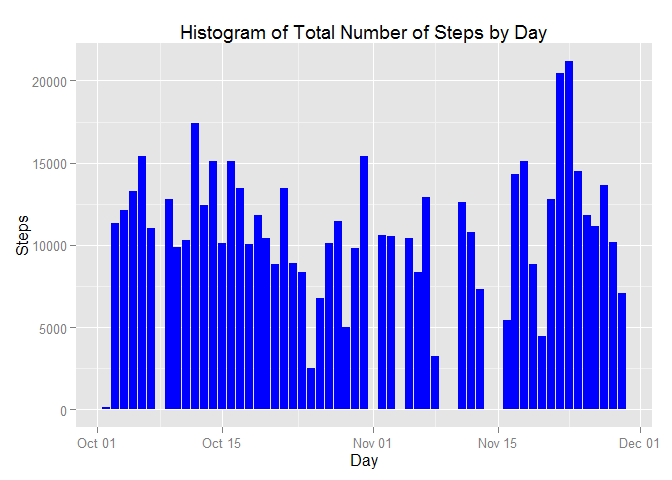

```r
ggplot(completeData, aes(x=date, y=steps)) +
    geom_histogram(stat="identity", fill = "blue") +
    labs(title="Histogram of Total Number of Steps by Day") +
    labs(x = "Day", y = "Steps")
```

Next, let’s look at a histogram of the total number of steps per day. In magenta, we have the mean steps taken per day. In blue, the median steps taken per day.

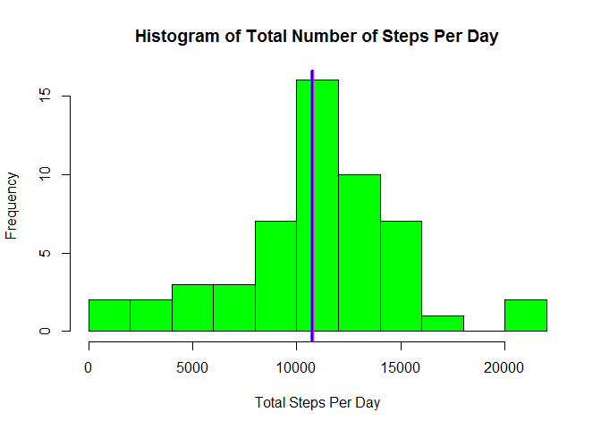

```r
hist(totalStepsPerDay, col="green", breaks=10,
     main = "Histogram of Total Number of Steps Per Day",
     xlab = "Total Steps Per Day")
abline(v = meanStepsPerDay, col ="magenta", lwd = 4)
abline(v = medianStepsPerDay, col = "blue", lwd=2)
```

The mean steps per day is 10,766.19. The median steps per day is 10,765.

## What is the average daily activity pattern?

Calculate the mean steps taken for each interval (averaged across all days). Then, plot the average.

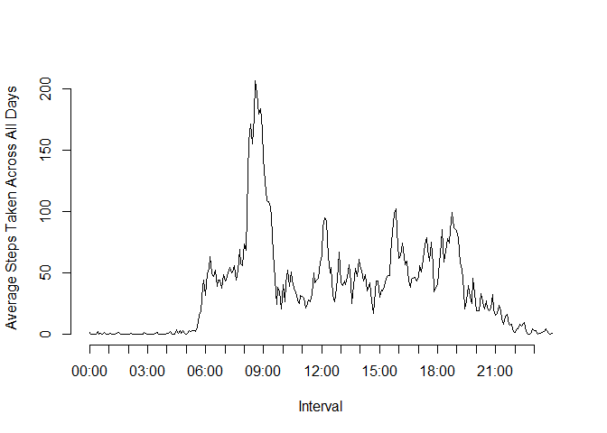

```r
meanStepsByInterval <- tapply(completeData$steps, completeData$time,
                              mean, na.rm = TRUE)
plot(meanStepsByInterval, axes = FALSE, t = "l", xlab="Interval",
     ylab = "Average Steps Taken Across All Days")
axis(2)
axis(1, at=seq(1,length(meanStepsByInterval),12),
     labels=unlist(dimnames(meanStepsByInterval))[seq(1,length(meanStepsByInterval),12)] )
```

```r
intervalWithMaxSteps <- names(which(meanStepsByInterval ==
                                        max(meanStepsByInterval)))
```

The interval with the maximum average across all days is 08:35.

## Imputing missing values

How many missing values are there?

```r
totalMissingRows <- sum(!complete.cases(data))
```

There are 2304 missing values in the original data set. We will replace these missing values with the mean (over all days) for that interval.

```r
newData <- data # new data frame to hold imputed data
# Get missing indices for steps
indexForNA <- which(is.na(newData$steps))
for (j in seq_along(indexForNA)) {
    newData[indexForNA[j], "steps"] <- as.integer(meanStepsByInterval[
        as.character(newData[indexForNA[j], "time"])])
}

newTotalMissingRows <- sum(!complete.cases(newData))
```

There are now 0 missing values in the imputed data set. Now let’s take a look at the total steps per day as a histogram, and the new mean (magenta) and median (blue).

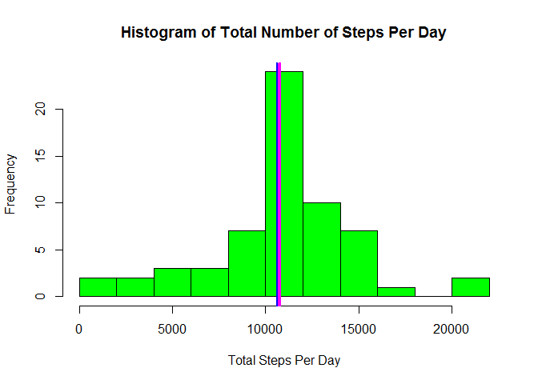

```r
newTotalStepsPerDay <- tapply(newData$steps, newData$date,
                           sum)
newMeanStepsPerDay <- mean(newTotalStepsPerDay)
newMedianStepsPerDay <- median(newTotalStepsPerDay)

hist(newTotalStepsPerDay, col="green", breaks=10,
     main = "Histogram of Total Number of Steps Per Day",
     xlab = "Total Steps Per Day")
abline(v = newMeanStepsPerDay, col ="magenta", lwd = 4)
abline(v = newMedianStepsPerDay, col = "blue", lwd=2)
```

The mean steps per day is 10,749.77. The median steps per day is 10,641. They are close to the original, but slightly lower. Overally, the imputing of the data kept the mean/median close to the originals.

## Are there differences in activity patterns between weekdays and weekends?

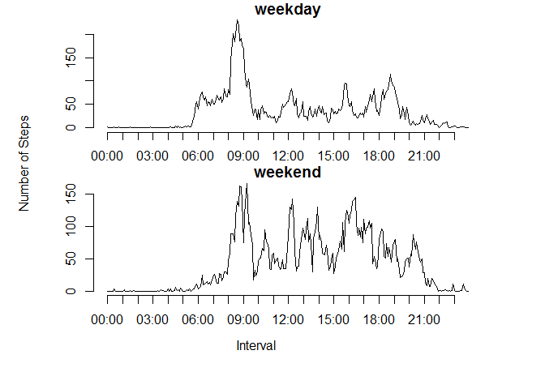

```r
# Calculate mean steps by dayType and interval
meanStepsByIntervalDayType <- with(newData, tapply(steps, list(dayType, time),
                                                   mean))

par(mfrow = c(2,1), mar = c(2,4,1,0), oma = c(4, 2, 0, 4))
plot(meanStepsByIntervalDayType[1, ], axes = FALSE,t = "l", main = "weekday", ylab = "", xlab = "")
axis(2)
axis(1, at=seq(1,length(meanStepsByIntervalDayType[1, ]),12),
     labels=unlist(names(meanStepsByIntervalDayType[1, ]))[seq(1,length(meanStepsByIntervalDayType[1, ]),12)] )
plot(meanStepsByIntervalDayType[2, ], axes = FALSE, t = "l", main = "weekend", ylab = "", xlab = "")
axis(2)
axis(1, at=seq(1,length(meanStepsByIntervalDayType[2, ]),12),
     labels=unlist(names(meanStepsByIntervalDayType[2, ]))[seq(1,length(meanStepsByIntervalDayType[2, ]),12)] )
mtext("Number of Steps", side = 2, outer = TRUE)
mtext("Interval", side=1, outer=TRUE, padj=1)
```

There are a lot more steps taken in the early morning on weekdays than on weekends. People walk later in the evenings on weekends. More steps are taken on weekends.